# Taller comprimido: cinco modelos de predicción numérica (vivienda)

# 1. Introducción

- En la sesión 3 (y el panorama de “otras técnicas”) vimos varias formas de **predecir un número**: regresión lineal, Ridge, Lasso, árboles de regresión y ensambles.
- Aquí las implementamos **todas sobre la misma base**, una de **política pública**: el **California Housing**. La tarea es predecir el **valor medio de la vivienda** de un vecindario a partir de características socioeconómicas (ingreso medio, antigüedad, población, ubicación…).
- Es un problema de **vivienda y desigualdad urbana**: dónde y por qué la vivienda es más cara, y qué tanto lo explica el ingreso del vecindario.
- Como el objetivo es **numérico**, ya no medimos “precisión”: comparamos los modelos con el **RMSE** (raíz del error cuadrático medio; menor es mejor).

# 2. Datos

```r
install.packages(c("glmnet", "rpart", "rpart.plot", "randomForest"))
```

- Datos públicos (censo de California). Así se obtienen (ya vienen en `data/`):

```r
url <- "https://raw.githubusercontent.com/ageron/handson-ml2/master/datasets/housing/housing.csv"
download.file(url, "data/california_housing.csv")
```

- Cargamos, quitamos las pocas filas con datos faltantes y la categoría “ISLAND” (solo 5 casos), y tomamos una muestra de 5000 para que corra rápido:

```r
casas <- read.csv("data/california_housing.csv", stringsAsFactors = TRUE)
casas <- casas[complete.cases(casas), ]                 # quita 207 filas sin total_bedrooms
casas <- casas[casas$ocean_proximity != "ISLAND", ]     # categoria rarisima (5 casos)
casas$ocean_proximity <- droplevels(casas$ocean_proximity)
set.seed(123)
casas <- casas[sample(nrow(casas), 5000), ]
summary(casas$median_house_value)
```

```
##    Min. 1st Qu.  Median    Mean 3rd Qu.    Max.
##   14999  120475  181100  209174  267525  500001
```

- El objetivo (`median_house_value`) está en dólares. Definimos una función para el **RMSE**, que usaremos con todos los modelos:

```r
rmse <- function(real, pred) sqrt(mean((real - pred)^2))
```

# 3. Partición entrenamiento / prueba

```r
set.seed(123)
idx <- sample(nrow(casas), 0.75 * nrow(casas))
entrena <- casas[idx, ]
prueba  <- casas[-idx, ]
verdad  <- prueba$median_house_value   # valores reales de la prueba
```

# 4. Regresión lineal (OLS)

- El punto de partida: una regresión lineal con todos los predictores.

```r
ols <- lm(median_house_value ~ ., data = entrena)
pred_ols <- predict(ols, prueba)
rmse(verdad, pred_ols)
```

```
## [1] 71258.23
```

# 5. Preparación para Ridge y Lasso

- `glmnet` (Ridge y Lasso) no recibe una fórmula: necesita una **matriz numérica** de predictores. La construimos con `model.matrix()` (convierte `ocean_proximity` en indicadoras). No hace falta normalizar: `glmnet` estandariza internamente.

```r
X <- model.matrix(median_house_value ~ . - 1, data = casas)
y <- casas$median_house_value
```

# 6. Ridge

- Ridge penaliza el tamaño de los coeficientes (los **encoge** hacia cero sin anularlos). `cv.glmnet` elige el nivel de penalización por validación cruzada:

```r
library(glmnet)
set.seed(123)
cv_ridge   <- cv.glmnet(X[idx, ], y[idx], alpha = 0)   # alpha = 0  ->  Ridge
pred_ridge <- predict(cv_ridge, X[-idx, ], s = "lambda.min")
rmse(verdad, pred_ridge)
```

```
## [1] 71863.86
```

# 7. Lasso

- Lasso también penaliza, pero puede llevar coeficientes **exactamente a cero**: hace **selección de variables**.

```r
set.seed(123)
cv_lasso   <- cv.glmnet(X[idx, ], y[idx], alpha = 1)   # alpha = 1  ->  Lasso
pred_lasso <- predict(cv_lasso, X[-idx, ], s = "lambda.min")
rmse(verdad, pred_lasso)
```

```
## [1] 71227.13
```

- Veamos cuáles coeficientes quedaron (los que aparecen como `.` fueron anulados):

```r
coef(cv_lasso, s = "lambda.min")
```

```
## 13 x 1 sparse Matrix of class "dgCMatrix"
##                                      s1
## (Intercept)               -2.318736e+06
## longitude                 -2.715562e+04
## latitude                  -2.552772e+04
## housing_median_age         1.196317e+03
## total_rooms               -6.734774e+00
## total_bedrooms             1.125815e+02
## population                -4.749234e+01
## households                 6.861315e+01
## median_income              4.078530e+04
## ocean_proximity<1H OCEAN   .
## ocean_proximityINLAND     -3.909724e+04
## ocean_proximityNEAR BAY   -4.467048e+03
## ocean_proximityNEAR OCEAN  1.054749e+04
```

# 8. Árbol de regresión

- Un árbol de regresión parte los datos en grupos y predice, en cada hoja, el **promedio** del valor de vivienda. Se puede visualizar:

```r
library(rpart)
library(rpart.plot)
arbol <- rpart(median_house_value ~ ., data = entrena)
pred_arbol <- predict(arbol, prueba)
rmse(verdad, pred_arbol)
```

```
## [1] 77287.3
```

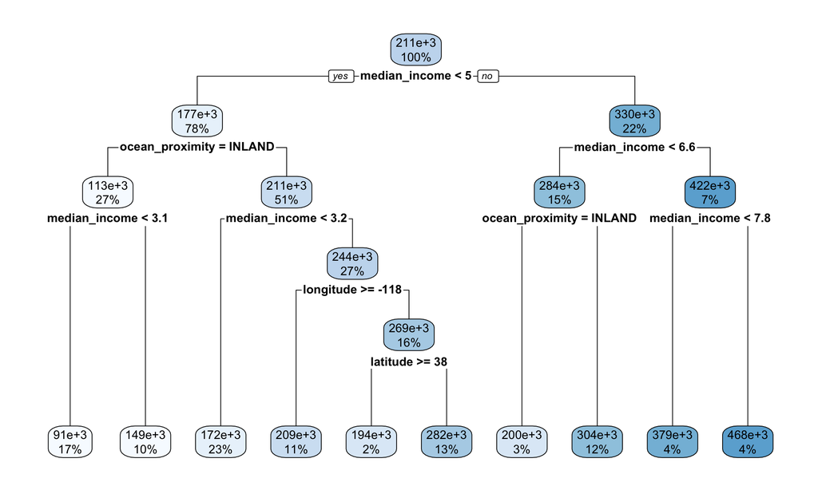

```r
rpart.plot(arbol)
```

# 9. Random Forest

- Un bosque promedia cientos de árboles y suele dar el menor error. Y nos dice qué variables pesan más:

```r
library(randomForest)
set.seed(123)
bosque <- randomForest(median_house_value ~ ., data = entrena)
pred_rf <- predict(bosque, prueba)
rmse(verdad, pred_rf)
```

```
## [1] 55440.76
```

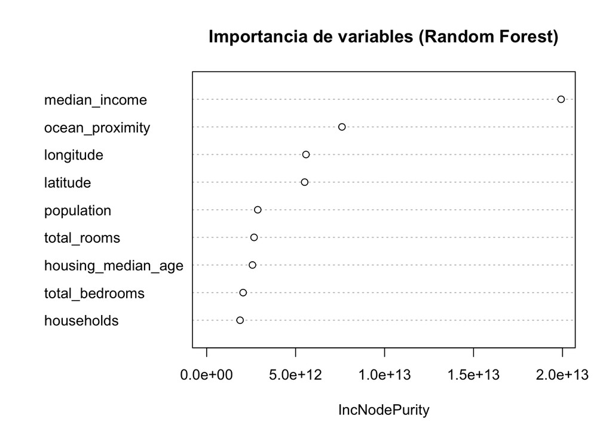

```r
varImpPlot(bosque, main = "Importancia de variables (Random Forest)")
```

# 10. Comparación

```r
rmse_todos <- c(
  OLS          = rmse(verdad, pred_ols),
  Ridge        = rmse(verdad, pred_ridge),
  Lasso        = rmse(verdad, pred_lasso),
  Arbol        = rmse(verdad, pred_arbol),
  RandomForest = rmse(verdad, pred_rf)
)
round(sort(rmse_todos), 0)   # menor es mejor
```

```
## RandomForest        Lasso          OLS        Ridge        Arbol
##        55441        71227        71258        71864        77287
```

[figure not shown]

```r
barplot(sort(rmse_todos, decreasing = TRUE), horiz = TRUE, las = 1,
        col = "steelblue", xlab = "RMSE en dólares (menor es mejor)",
        main = "Comparación de modelos de predicción numérica")
```

- Lecciones:
  1. **Random Forest** suele dar el menor RMSE, pero es una “caja negra”; **OLS** es peor predictor pero **interpretable** (puedes leer el efecto de cada variable). Es el *trade-off* de siempre.
  2. **Ridge y Lasso** se parecen mucho a OLS aquí, porque hay **pocos predictores**. Su ventaja brilla cuando hay **muchas** variables (decenas o cientos), donde controlan el sobreajuste y, en el caso de Lasso, **seleccionan** las relevantes.
  3. El predictor dominante es el **ingreso medio** del vecindario: una lectura directa de **desigualdad** en el acceso a la vivienda.